# Run trajectory analysis with Lagranto

[Lagrangian analysis tool Lagranto](https://gmd.copernicus.org/articles/8/2569/2015/gmd-8-2569-2015.html) provides provide functionalities to calcualte Lagrangian trajectories from reanalysis data. Lagranto is origionally written in FORTRAN and excuted in bash script. A python wrapper of Lagranto is created to run Lagranto in Jupyter notebook.

In this notebook, we will go through steps of calculating trajectories.

```python
import os
import sys
import numpy as np
import pandas as pd
import xarray as xr
from IPython.display import HTML

# the path to the repository of lagranto python wrapper
sys.path.append("/g/data/if69/cj0591/repos/lagranto")
from utils.lagranto_utils import run_Lagranto
from utils.tools import track_map, modify_lagranto_output, track_animation
from utils.starf import create_starf_point, create_starf_line, create_starf_box
```

LAGRANTO is assumed to be installed in the following directory on Gadi.

`/home/565/cj0591/lagranto.fortran`

For install Lagranto on Gadi, please concat [Chenhui Jin](https://www.21centuryweather.org.au/profile/chenhui-jin/)

**Step 1** - We first set a couple directories.

- `work_dir` refers to the directory of lagranto python wrapper

```python
work_dir = "/g/data/if69/cj0591/repos/lagranto"
```

- `LAGRANTODIR` refers to the directory where the orginal Lagranto code is located

```python
os.environ['LAGRANTODIR']="/home/565/cj0591/lagranto.fortran"
```

- `era5dir` refers to the directory where input data (called **P files**) is located

```python
era5dir = f"/scratch/if69/cj0591/lagranto/era5/"
```

- `outpdir` refers to the directory where output data (trajectory) is located

```python
outpdir = f"{work_dir}/output/trajectory.fortranT"
```

- `statdir` refers to the directory where starting positions are located

```python
statdir = f"{work_dir}/startf/startf.fortranonlyT"
```

**P files** should be ready before running Lagranto in this notebook.

At an instanously time, a **P file** contains:

- **U** (three-dimensional zonal wind)
- **V** (three-dimensional meridional wind)
- **OMEGA** (three-dimensional vertical velocity in Pa/s)
- **PS** (two-dimensional surface pressure)

⚠️ **Note:** These four variables are **compulsory** for running trajectories!

A P file is netcdf file, named as `PYYYYMMdd_HH`, in which `YYYY` represents year, `MM` represent month, `dd` represent day, and `HH` represents hour, e.g., P20241202_12

An exmaple P file (`P20241202_12`) is shown below:

```python
example_Pfile = xr.open_dataset(f"{era5dir}/P20241202_12")
example_Pfile
```

```
<xarray.Dataset>
Dimensions:  (lev: 37, lat: 361, lon: 720, time: 1)
Coordinates:
  * lev      (lev) int32 100 200 300 500 700 ... 90000 92500 95000 97500 100000
  * lat      (lat) float32 -90.0 -89.5 -89.0 -88.5 -88.0 ... 88.5 89.0 89.5 90.0
  * lon      (lon) float32 -180.0 -179.5 -179.0 -178.5 ... 178.5 179.0 179.5
  * time     (time) datetime64[ns] 2024-12-02T12:00:00
Data variables:
    U        (time, lev, lat, lon) float32 ...
    V        (time, lev, lat, lon) float32 ...
    OMEGA    (time, lev, lat, lon) float32 ...
    PS       (time, lat, lon) float32 ...
```

To run trajectory, multiple **P files** are needed, e.g.,  
`P20241201_00`, `P20241201_06`, `P20241201_18`, `P20241202_00`, ...

**P files** are generated using the Python script `get_Pfile.py` under `work_dir`. For submitting PBS job, user can use `get_Pfile.sh`

**Step 2** - We now generate some starting positions

For starting positions in a box, using `create_starf_box`

**Parameters:**

- **statdir** - directory of starting positions as set before
- **lon_min** - lower bound of longitude
- **lon_max** - upper bound of longitude
- **lat_min** - lower bound of latitude
- **lat_max** - upper bound of latitude
- **interval** - grid spacing in degree
- **lev_range** - list of pressure levels

```python
create_starf_box(statdir, 140 ,150, 30, 40, 1, [925, 800, 700, 600, 500])
```

**Step 3** - Calculate trajectory with Lagranto python wrapper

For starting positions in a box, using `run_Lagranto`

**Parameters:**

- **statdir** - directory of starting positions as set before
- **period** - length of period (in hours). Minus sigh indicates backward trajectory, e.g., -120 means 120 hours backward
- **outputdir** - directory where output data (trajectory) is located
- **input_interval** - time interval for input P files (in minitues, e.g., 360 minitues = 6 hours)
- **output_interval** - time interval for output trajectory files (in minitues, e.g., 360 minitues = 6 hours)
- **reference_date** - the start date when trajectories are calcualted
- **era5dir** - directory where P files are located
- **quiet** - False or True

For the example, we would like to calcualte 120-hour bacjkward trajectories (`period=-120`), starting at UTC 12 on 2nd December 2024 (`reference_date="20241202_12"`)

```python
reference_date = "20241202_12"
period = -120

run_Lagranto(statdir, period, outpdir, 360, 360, reference_date, era5dir,
             quiet=True)
```

**Step 4** - Modify the output and create a track map

The output trajectories are read into pandas dataframe using `modify_lagranto_output`.

```python
df = modify_lagranto_output(outpdir)
df.head(21)
```

|  | time | lon | lat | p | track_id |
| --- | --- | --- | --- | --- | --- |
| 0 | 0.0 | 140.00 | 30.00 | 925 | 1 |
| 1 | -6.0 | 140.27 | 30.09 | 909 | 1 |
| 2 | -12.0 | 139.86 | 30.31 | 884 | 1 |
| 3 | -18.0 | 138.54 | 30.68 | 865 | 1 |
| 4 | -24.0 | 136.39 | 30.71 | 836 | 1 |
| 5 | -30.0 | 134.14 | 30.29 | 814 | 1 |
| 6 | -36.0 | 132.19 | 29.66 | 807 | 1 |
| 7 | -42.0 | 130.80 | 28.86 | 792 | 1 |
| 8 | -48.0 | 130.33 | 28.49 | 810 | 1 |
| 9 | -54.0 | 129.79 | 28.88 | 804 | 1 |
| 10 | -60.0 | 128.30 | 29.65 | 768 | 1 |
| 11 | -66.0 | 126.35 | 30.56 | 749 | 1 |
| 12 | -72.0 | 124.08 | 32.22 | 727 | 1 |
| 13 | -78.0 | 121.31 | 34.81 | 677 | 1 |
| 14 | -84.0 | 118.21 | 38.90 | 607 | 1 |
| 15 | -90.0 | 115.59 | 44.33 | 559 | 1 |
| 16 | -96.0 | 113.21 | 50.41 | 546 | 1 |
| 17 | -102.0 | 109.70 | 56.29 | 524 | 1 |
| 18 | -108.0 | 101.11 | 61.35 | 518 | 1 |
| 19 | -114.0 | 86.90 | 65.11 | 498 | 1 |
| 20 | -120.0 | 66.09 | 67.05 | 516 | 1 |

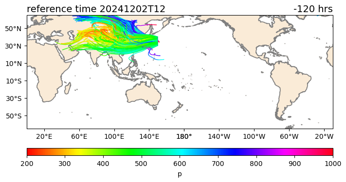

```python
fig_traj = track_map(df,
                     'p', 200, 1000,
                      0, 350, -65, 65,
                     'hsv',
                     f'reference time {reference_date[0:8]}T{reference_date[9:]}',
                     f'{str(period)} hrs')
```

```python
# animation
anim_track = track_animation(df,
                            'p', 200, 1000,
                             0, 350, -65, 65,
                             125,
                             f'Reference time {reference_date[0:8]}T{reference_date[9:]}')
HTML(anim_track.to_jshtml())
```

[figure not shown]